# ds202_lab4

Patrick Origer

10/7/2020

## R Markdown

```r
library(reshape2)
library(tidyr)
library(dplyr)
```

```r
library(readxl)
library(ggplot2)

defensive <- read_excel('C:/Users/15154/Downloads/cyclonesFootball2019.xlsx', sheet='Defensive')
offensive <- read_excel('C:/Users/15154/Downloads/cyclonesFootball2019.xlsx', sheet='Offensive')
biography <- read_excel('C:/Users/15154/Downloads/cyclonesFootball2019.xlsx', sheet='Biography')
```

1. Cleaning Biography Sheet

```r
biography <- biography %>% mutate(Weight=as.numeric(Weight)) %>%
  separate(Height, into = c('Feet', 'Inches'), sep = '-') %>%
  mutate(Feet = as.numeric(Feet), Inches = as.numeric(Inches), Height= Feet * 12 + Inches)

bio2019 <- biography

bioClean <- biography
str(bioClean)
```

```
## tibble [105 x 9] (S3: tbl_df/tbl/data.frame)
##  $ Name      : chr [1:105] "Akers, Landen" "Allen, Chase" "Anderson, Ezeriah" "Assalley, Connor" ...
##  $ Position  : chr [1:105] "Wide Receiver" "Tight End" "Wide Receiver" "Placekicker" ...
##  $ Feet      : num [1:105] 6 6 6 6 6 6 6 6 6 6 ...
##  $ Inches    : num [1:105] 0 7 5 0 0 3 2 2 0 6 ...
##  $ Weight    : num [1:105] 188 245 204 195 190 235 255 285 300 215 ...
##  $ Class     : chr [1:105] "Redshirt Senior" "Redshirt Senior" "Redshirt Freshman" "Redshirt Senior" ...
##  $ Hometown  : chr [1:105] "Cedar Rapids, Iowa" "Nixa, Mo." "Seffner, Fla." "Naperville, Ill." ...
##  $ Highschool: chr [1:105] "Washington" "Nixa" "Armwood" "Central" ...
##  $ Height    : num [1:105] 72 79 77 72 72 75 74 74 72 78 ...
```

1. Cleaning Defensive Sheet

```r
defensive <- defensive %>% mutate(Name=as.factor(Name), Opponent_Opponent=as.factor(Opponent_Opponent)) %>%
  mutate(across(where(is.character), as.numeric))

def2019 <- defensive

defClean <- defensive
str(defClean)
```

```
## tibble [502 x 11] (S3: tbl_df/tbl/data.frame)
##  $ Name             : Factor w/ 43 levels "Akers, Landen",..: 40 40 40 40 40 40 40 40 40 40 ...
##  $ Opponent_Opponent: Factor w/ 13 levels "Baylor","Iowa",..: 12 2 11 1 8 13 10 7 6 9 ...
##  $ Tackles_Solo     : num [1:502] 4 4 3 4 3 1 7 3 6 5 ...
##  $ Tackles_ASST     : num [1:502] 4 7 5 2 2 1 1 2 1 5 ...
##  $ Tackles_TFL      : num [1:502] 0 0 0 0 1 0 0 0 1 1 ...
##  $ Tackles_Sack     : num [1:502] 0 0 0 0 0 0 0 0 0 1 ...
##  $ Turnover_FF      : num [1:502] 0 0 0 0 0 0 0 0 0 0 ...
##  $ Turnover_FR      : num [1:502] 0 0 0 0 0 0 0 0 0 0 ...
##  $ Turnover_INT     : num [1:502] 0 0 1 0 0 0 0 0 1 0 ...
##  $ Pass_QBH         : num [1:502] 1 0 0 0 0 0 0 0 1 0 ...
##  $ Pass_PB          : num [1:502] 1 2 0 0 0 1 0 0 0 0 ...
```

1. Cleaning Offensive Sheet

```r
offensive <- offensive %>% mutate(Name=as.factor(Name), Opponent_Opponent=as.factor(Opponent_Opponent)) %>%
  mutate(across(where(is.character), as.numeric))
off2019 <- offensive

offClean = offensive
str(offClean)
```

```
## tibble [195 x 12] (S3: tbl_df/tbl/data.frame)
##  $ Name             : Factor w/ 17 levels "Akers, Landen",..: 1 1 1 1 1 1 1 1 1 1 ...
##  $ Opponent_Opponent: Factor w/ 13 levels "Baylor","Iowa",..: 12 2 11 1 8 13 10 7 6 9 ...
##  $ Rushing_ATT      : num [1:195] 0 0 1 0 0 0 0 0 0 0 ...
##  $ Rushing_YDS      : num [1:195] 0 0 8 0 0 0 0 0 0 0 ...
##  $ Rushing_TD       : num [1:195] 0 0 0 0 0 0 0 0 0 0 ...
##  $ Receiving_REC    : num [1:195] 1 0 0 0 1 0 0 4 0 1 ...
##  $ Receiving_YDS    : num [1:195] 21 0 0 0 32 0 0 39 0 7 ...
##  $ Receiving_TD     : num [1:195] 0 0 0 0 0 0 0 0 0 0 ...
##  $ Passing_CMP-ATT  : num [1:195] NA NA NA NA NA NA NA NA NA NA ...
##  $ Passing_YDS      : num [1:195] NA NA NA NA NA NA NA NA NA NA ...
##  $ Passing_TD       : num [1:195] NA NA NA NA NA NA NA NA NA NA ...
##  $ Passing_INT      : num [1:195] NA NA NA NA NA NA NA NA NA NA ...
```

```r
defPrePivot <- defClean
defClean <- defClean %>% pivot_longer(Tackles_Solo:Pass_PB, names_to = 'stat')
```

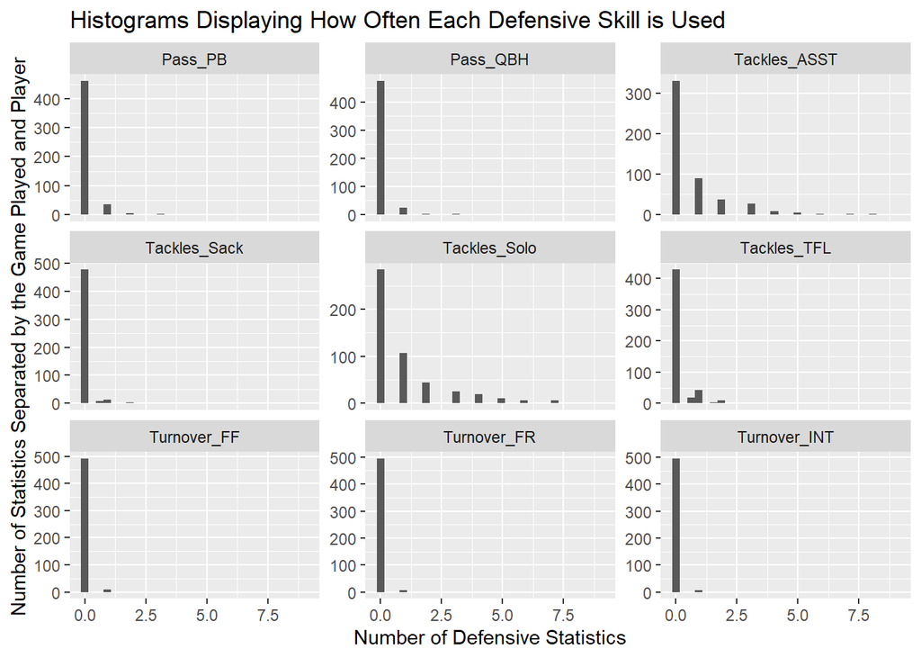

```r
ggplot(defClean, aes(x = value)) + geom_histogram() + facet_wrap(~stat, scales = 'free_y') +
  labs(title = "Histograms Displaying How Often Each Defensive Skill is Used", x = "Number of Defensive Statistics", y = "Number of Statistics Separated by the Game Played and Player")
```

2. Question 2: The rarest skills seem to be Turnover_FF, Turnover_FR, Turnover_NT, and Tackles_Sack.

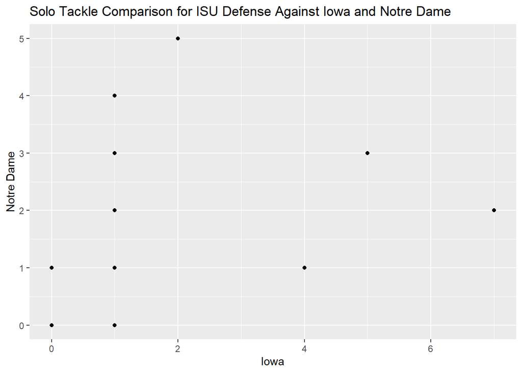

```r
defQ2 <- defClean
defQ2 <- defQ2 %>% filter(Opponent_Opponent %in% c("Iowa", "Notre Dame"), stat == "Tackles_Solo") %>%
  pivot_wider(names_from = 'Opponent_Opponent', values_from = 'value')

defQ2 <- rename(defQ2, Notre_Dame = 'Notre Dame')

ggplot(defQ2, aes(x = Iowa, y = Notre_Dame)) +
  geom_point() +
  labs(title = "Solo Tackle Comparison for ISU Defense Against Iowa and Notre Dame", y = "Notre Dame")
```

2. Question 3: ISU had played good defense against Notre Dame.
3. Question 4: Completed below.

```r
bioClean <- bioClean %>% separate(Hometown, into = c("Town", "State"), sep = ", ")

head(bioClean)
```

```
## # A tibble: 6 x 10
##   Name     Position    Feet Inches Weight Class   Town   State Highschool Height
##   <chr>    <chr>      <dbl>  <dbl>  <dbl> <chr>   <chr>  <chr> <chr>       <dbl>
## 1 Akers, ~ Wide Rece~     6      0    188 Redshi~ Cedar~ Iowa  Washington     72
## 2 Allen, ~ Tight End      6      7    245 Redshi~ Nixa   Mo.   Nixa           79
## 3 Anderso~ Wide Rece~     6      5    204 Redshi~ Seffn~ Fla.  Armwood        77
## 4 Assalle~ Placekick~     6      0    195 Redshi~ Naper~ Ill.  Central        72
## 5 Azunna,~ Defensive~     6      0    190 Redshi~ Grand~ Texas Lake Ridge     72
## 6 Bailey,~ Defensive~     6      3    235 Redshi~ Clark~ Miss. Clarksdale     75
```

```r
bioQ2 <- bioClean %>% group_by(State) %>%
  summarise(count = n()) %>%
  arrange(desc(count))
bioQ2
```

```
## # A tibble: 19 x 2
##    State     count
##    <chr>     <int>
##  1 Iowa         35
##  2 Fla.         10
##  3 Ohio          7
##  4 Mo.           6
##  5 Texas         6
##  6 Wis.          6
##  7 Ill.          5
##  8 Ariz.         4
##  9 Ga.           4
## 10 Mich.         4
## 11 Minn.         4
## 12 Calif.        3
## 13 Kan.          3
## 14 Okla.         2
## 15 S.D.          2
## 16 Ark.          1
## 17 Australia     1
## 18 Miss.         1
## 19 Pa.           1
```

2. Part 5: Above is the number of ISU players from each state.

```r
offDatStates <- offClean %>% select(Name)
offDatStates <- distinct(offDatStates)

defDatStates <- defClean %>% select(Name)
defDatStates <- distinct(defDatStates)

defStates <- left_join(defDatStates, bioClean) %>%
  select(Name, State)
offStates <- left_join(offDatStates, bioClean) %>%
  select(Name, State)
```

[figure not shown]

```r
ggplot(defStates, aes(State)) + geom_histogram(stat = "count") + labs(title = "Number of Offensive ISU Players From Each State", y = "Number of Players")
```

[figure not shown]

```r
ggplot(offStates, aes(State)) + geom_histogram(stat = "count") + labs(title = "Number of Defensive ISU Players From Each State", y = "Number of Players")
```

```r
offClean <- offClean  %>% mutate(Total_YDS = ifelse(is.na(Rushing_YDS), 0, Rushing_YDS) + ifelse(is.na(Receiving_YDS), 0, Receiving_YDS) + ifelse(is.na(Passing_YDS), 0, Passing_YDS)) %>%
  mutate(isPurdy = ifelse(Name == "Purdy, Brock", "Brock Purdy", "Not Brock Purdy"))
```

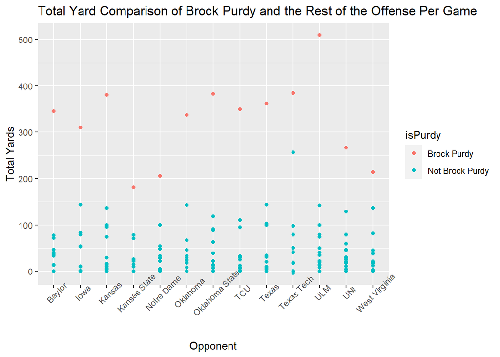

```r
ggplot(offClean, aes(x=Opponent_Opponent, y=Total_YDS)) +
  geom_point(aes(colour = isPurdy)) +
  theme(axis.text.x =element_text(angle=45)) +
  labs(title = "Total Yard Comparison of Brock Purdy and the Rest of the Offense Per Game", x = "Opponent", y = "Total Yards")
```

```r
offBP <- offClean %>% group_by(isPurdy, Opponent_Opponent) %>%
  summarise(Mean_Total_YDS = mean(Total_YDS, na.rm = TRUE),
            Sum_Total_YDS = sum(Total_YDS, na.rm = TRUE)) %>%
  arrange(Opponent_Opponent)
offBP
```

```
## # A tibble: 26 x 4
## # Groups:   isPurdy [2]
##    isPurdy         Opponent_Opponent Mean_Total_YDS Sum_Total_YDS
##    <chr>           <fct>                      <dbl>         <dbl>
##  1 Brock Purdy     Baylor                     345             345
##  2 Not Brock Purdy Baylor                      28.7           402
##  3 Brock Purdy     Iowa                       310             310
##  4 Not Brock Purdy Iowa                        33.5           435
##  5 Brock Purdy     Kansas                     381             381
##  6 Not Brock Purdy Kansas                      34.4           481
##  7 Brock Purdy     Kansas State               182             182
##  8 Not Brock Purdy Kansas State                18.8           244
##  9 Brock Purdy     Notre Dame                 206             206
## 10 Not Brock Purdy Notre Dame                  22.5           293
## # ... with 16 more rows
```

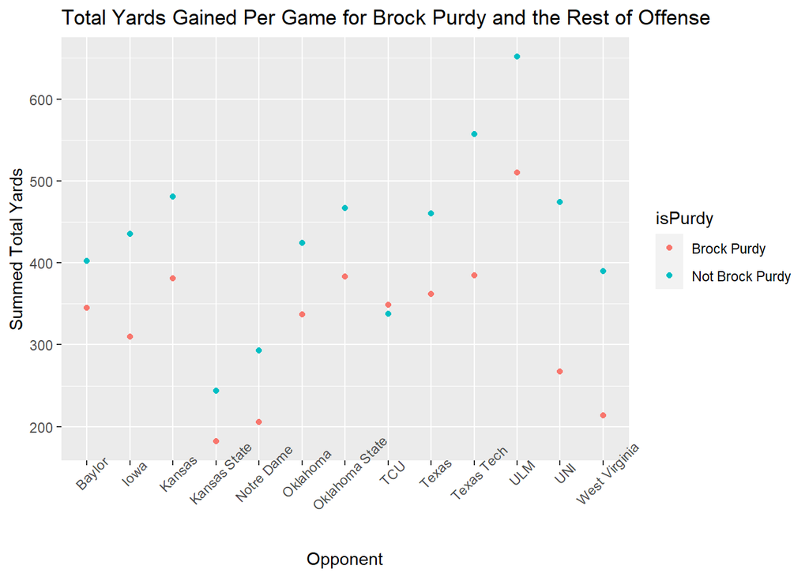

```r
ggplot(offBP, aes(x=Opponent_Opponent, y=Sum_Total_YDS)) +
  geom_point(aes(colour = isPurdy)) +
  theme(axis.text.x =element_text(angle=45)) +
  labs(title = "Total Yards Gained Per Game for Brock Purdy and the Rest of Offense", x = "Opponent", y = "Summed Total Yards")
```

3. Question 2: It seems that Brock Purdy’s performance and the rest of the offense perform consistent with one another. When Brock Purdy earns high amounts of yards in a game, the rest of the offense typically also receives high amounts of yards and vice ce versa.

```r
defensive2018 <- read_excel('C:/Users/15154/Downloads/cyclonesFootball2018.xlsx', sheet='Defensive')
offensive2018 <- read_excel('C:/Users/15154/Downloads/cyclonesFootball2018.xlsx', sheet='Offensive')
biography2018 <- read_excel('C:/Users/15154/Downloads/cyclonesFootball2018.xlsx', sheet='Biography')
```

```r
biography2018 <- biography2018 %>% mutate(Weight=as.numeric(Weight)) %>%
  separate(Height, into = c('Feet', 'Inches'), sep = '-') %>%
  mutate(Feet = as.numeric(Feet), Inches = as.numeric(Inches), Height= Feet * 12 + Inches)

offensive2018 <- offensive2018 %>% mutate(Name=as.factor(Name), Opponent_Opponent=as.factor(Opponent_Opponent)) %>%
  mutate(across(where(is.character), as.numeric))
offensiveQ3 <- offensive2018 %>% mutate(Total_YDS = ifelse(is.na(Rushing_YDS), 0, Rushing_YDS) + ifelse(is.na(Receiving_YDS), 0, Receiving_YDS) + ifelse(is.na(Passing_YDS), 0, Passing_YDS)) %>%
  group_by(Name) %>%
  summarise(Total_Yards_2018 = sum(Total_YDS))
off2019 <- off2019 %>% mutate(Name=as.factor(Name), Opponent_Opponent=as.factor(Opponent_Opponent)) %>%
  mutate(across(where(is.character), as.numeric))

off2019 <- off2019 %>% mutate(Total_YDS = ifelse(is.na(Rushing_YDS), 0, Rushing_YDS) + ifelse(is.na(Receiving_YDS), 0, Receiving_YDS) + ifelse(is.na(Passing_YDS), 0, Passing_YDS)) %>%
  group_by(Name) %>%
  summarise(Total_Yards_2019 = sum(Total_YDS))
offensiveQ3 <- full_join(offensiveQ3, off2019, by = c("Name" = "Name")) %>%
  drop_na(Total_Yards_2018, Total_Yards_2019) %>%
  mutate(Yardage_Improvement_Ratio = Total_Yards_2019 / Total_Yards_2018, Yards_Difference = Total_Yards_2019 - Total_Yards_2018) %>%
  arrange(desc(Yards_Difference))

offensiveQ3
```

```
## # A tibble: 8 x 5
##   Name     Total_Yards_2018 Total_Yards_2019 Yardage_Improveme~ Yards_Difference
##   <fct>               <dbl>            <dbl>              <dbl>            <dbl>
## 1 Purdy, ~             2558             4231              1.65              1673
## 2 Jones, ~              366              931              2.54               565
## 3 Kolar, ~              137              697              5.09               560
## 4 Milton,~              420              722              1.72               302
## 5 Lang, J~              109              292              2.68               183
## 6 Allen, ~               84              167              1.99                83
## 7 Nwangwu~              168              123              0.732              -45
## 8 Akers, ~              181              117              0.646              -64
```

```r
defensive2018 <- defensive2018 %>% mutate(Name=as.factor(Name), Opponent_Opponent=as.factor(Opponent_Opponent)) %>%
  mutate(across(where(is.character), as.numeric))

defensive2018 <- defensive2018 %>% mutate(Tackle_Interactions_2018 = Tackles_Solo + Tackles_ASST + Tackles_TFL + Tackles_Sack) %>% group_by(Name) %>%
  summarise(Total_Tackles_2018 = sum(Tackle_Interactions_2018))
def2019 <- def2019 %>% mutate(Tackle_Interactions_2019 = Tackles_Solo + Tackles_ASST + Tackles_TFL + Tackles_Sack) %>%
  group_by(Name) %>%
  summarise(Total_Tackles_2019 = sum(Tackle_Interactions_2019))
defensiveQ3 <- full_join(defensive2018, def2019) %>%
  drop_na(Total_Tackles_2018, Total_Tackles_2019) %>%
  mutate(Tackle_Improvement_Ratio = Total_Tackles_2019 / Total_Tackles_2018, Tackle_Difference = Total_Tackles_2019 - Total_Tackles_2018) %>%
  arrange(desc(Tackle_Difference))
defensiveQ3
```

```
## # A tibble: 28 x 5
##    Name    Total_Tackles_20~ Total_Tackles_2~ Tackle_Improveme~ Tackle_Differen~
##    <fct>               <dbl>            <dbl>             <dbl>            <dbl>
##  1 Vance,~              30               81.5              2.72             51.5
##  2 Peters~               4               48.5             12.1              44.5
##  3 Johnso~              29               69                2.38             40
##  4 White,~              53.5             89                1.66             35.5
##  5 Azunna~               8               32                4                24
##  6 McDona~               5               27                5.4              22
##  7 Akers,~               1               11               11                10
##  8 Wallin~               3               11                3.67              8
##  9 Young,~              12               20                1.67              8
## 10 Robert~               1                8                8                 7
## # ... with 18 more rows
```

3. Question 3: For offense, it seems that Charlie Kolar improved his yardage from 2018 to 2019 multiple times over. Brock Purdy possessed the greatest yardage increase of all offense with 1673 more yards in 2019 than 2018.

For Defense, it appears that O’Rien Vance had the greatest improvement in total number of tackle interactions moving from 2018 to 2019. Although, Zach Petersen had the highest tackle improvement ratio. Going from only 4 tackle interactions in 2018 to 48.5 in 2019.

Each of the players discussed above made large improvements from 2018 to 2019.